# Projet: Sondage d'opinion

#### Mes Variables:

- **`SEXE`** : elle prend 2 valeur soit F: female ou M: male
- **`Experience`** : le nombre d'annees que l'employe a travailler a JTI.
- **`Departement_JTI`** : le departement en quel l'employe travail.
- **`Experience_poste_ans`** : le nombre d'annees que l'employe travaille dans son poste actuel.
- **`Office`** : le pays où travaille l'employe.
- **`Evaluation_benifice`** : l'evaluation de l'enqueté d'apres son opinion (a un echele de 5: pire 1 ---> 5 meilleur ) le benifice des etudiants de cette platform.
- **`Evaluation_idee`** : l'evaluation de l'enqueté d'apres son opinion (a un echele de 5: pire 1 ---> 5 meilleur ) le benifice de l'entreprise JTI de cette platform.
- **`Creation_contenu`** : l'enqueté veut-il creer le contenu de la platform. (oui: 1 , non: 0)
- **`Creation_video`** : l'enqueté veut-il apparaître dans les videos de la platform. (oui: 1 , non: 0)
- **`Encadrement`** : l'enqueté veut-il encadre les etudiants utilisateurs de la platform. (oui: 1 , non: 0)
- **`Consultation`** : l'enqueté veut-il repondre aux questions et difficultes des etudiants utilisateurs sur la platform. (oui: 1 , non: 0)
- **`Creation_corrige_type`** : l'enqueté veut-il creer des corrige type des travail a faire sur la platform. (oui: 1 , non: 0)
- **`recompance`** : l'enqueté veut-il être récompensé par de l'argent, de l'expérience, une carte de remerciement ou des cadeaux pour sa participation volontaire a la platforme.
- **`Evaluation_Enthousiasme`** : l'evaluation de l'enqueté de son enthousiasme a participer a la platforme. (a un echele de 5: pire 1 ---> 5 meilleur )
- **`exp_en_design`** : l'enqueté à-il une expérience dans le graphic design. (oui: 1 , non: 0)
- **`exp_en_encadrement`** : l'enqueté à-il une expérience dans l'encadrement des stagiaires. (oui: 1 , non: 0)
- **`besoin_de_formation`** : l'enqueté pense-il qu'il a besoin d'une formation pour mieux participer à la plateforme. (oui: 1 , non: 0)
- **`heure`** : combien d'heures par semaine le répondant est-il prêt à consacrer à sa participation à la plateforme.

```python
print('le nombre de ligne :', df.shape[0])
print('le nombre de colonne :', df.shape[1])
```

```
le nombre de ligne : 43
le nombre de colonne : 18
```

```python
# type des variables de la base de donnees
df.dtypes
```

```
SEXE                       object
Experience_ans              int64
Departement_JTI            object
Experience_poste_ans        int64
Office                     object
evaluation_benifice         int64
evaluation_idee             int64
creation_contenu            int64
creation_video              int64
encadrement                 int64
consultation                int64
creation_corrige_type       int64
recompanse                 object
evaluation_enthousiasme     int64
exp_en_design               int64
exp_en_encadrement          int64
besoin_de_formation         int64
Heure                       int64
dtype: object
```

```python
df.isnull().sum()
```

```
SEXE                       2
Experience_ans             0
Departement_JTI            0
Experience_poste_ans       0
Office                     3
evaluation_benifice        0
evaluation_idee            0
creation_contenu           0
creation_video             0
encadrement                0
consultation               0
creation_corrige_type      0
recompanse                 2
evaluation_enthousiasme    0
exp_en_design              0
exp_en_encadrement         0
besoin_de_formation        0
Heure                      0
dtype: int64
```

```python
# pour la variavle office, je vois que pour la même valeur a été écrite de différentes manières.
df.Office.value_counts()
```

```
alger         6
Casablanca    6
morocco       4
tunis         4
tunisia       4
ALGERIA       3
Algiers       3
algiers       2
algeria       2
Tunisia       2
Algeria       1
CASABLANCA    1
Tunis         1
Alger         1
Name: Office, dtype: int64
```

```python
df.Office.replace(['alger', 'ALGERIA','Algiers','algiers', 'Alger','algeria'], 'Algeria' , inplace=True)
df.Office.replace(['Casablanca', 'morocco','CASABLANCA'], 'Morocco' , inplace=True)
df.Office.replace(['tunisia', 'tunis','tunis', 'Tunis'], 'Tunisia' , inplace=True)
df.Office.value_counts()
```

```
Algeria    18
Tunisia    11
Morocco    11
Name: Office, dtype: int64
```

```python
# il n'y a pas de lignes en double
df.duplicated().sum()
```

```
0
```

il n'y a pas de ligne en double, cela donne une idée que la saisie des données a été effectuée correctement

## Statistique descriptive :

```python
a = df.describe(include= 'all')
a.rename(index={'unique': 'valeur unique', 'top': 'valeur la plus frequente', 'freq': 'frequence', 'mean': 'moyenne', 'std': 'ecart type'}, inplace=True)
a.fillna('-')
```

|  | SEXE | Experience_ans | Departement_JTI | Experience_poste_ans | Office | evaluation_benifice | evaluation_idee | creation_contenu | creation_video | encadrement | consultation | creation_corrige_type | recompanse | evaluation_enthousiasme | exp_en_design | exp_en_encadrement | besoin_de_formation | Heure |
| --- | --- | --- | --- | --- | --- | --- | --- | --- | --- | --- | --- | --- | --- | --- | --- | --- | --- | --- |
| count | 41 | 43 | 43 | 43 | 40 | 43 | 43 | 43 | 43 | 43 | 43 | 43 | 41 | 43 | 43 | 43 | 43 | 43 |
| valeur unique | 2 | - | 11 | - | 3 | - | - | - | - | - | - | - | 4 | - | - | - | - | - |
| valeur la plus frequente | F | - | G&A | - | Algeria | - | - | - | - | - | - | - | Thank you card | - | - | - | - | - |
| frequence | 21 | - | 7 | - | 18 | - | - | - | - | - | - | - | 19 | - | - | - | - | - |
| moyenne | - | 6.44186 | - | 3.2093 | - | 3.13953 | 2.95349 | 0.55814 | 0.465116 | 0.488372 | 0.44186 | 0.372093 | - | 4.02326 | 0.488372 | 0.44186 | 0.744186 | 3.95349 |
| ecart type | - | 3.48673 | - | 2.53131 | - | 1.33776 | 1.58795 | 0.502486 | 0.504685 | 0.505781 | 0.502486 | 0.489083 | - | 0.963337 | 0.505781 | 0.502486 | 0.441481 | 2.13757 |
| min | - | 1 | - | 1 | - | 1 | 1 | 0 | 0 | 0 | 0 | 0 | - | 1 | 0 | 0 | 0 | 1 |
| 25% | - | 4 | - | 1 | - | 2.5 | 1 | 0 | 0 | 0 | 0 | 0 | - | 3 | 0 | 0 | 0.5 | 2 |
| 50% | - | 6 | - | 2 | - | 3 | 3 | 1 | 0 | 0 | 0 | 0 | - | 4 | 0 | 0 | 1 | 4 |
| 75% | - | 10 | - | 4 | - | 4 | 4 | 1 | 1 | 1 | 1 | 1 | - | 5 | 1 | 1 | 1 | 6 |
| max | - | 11 | - | 10 | - | 5 | 5 | 1 | 1 | 1 | 1 | 1 | - | 5 | 1 | 1 | 1 | 7 |

- pour chaque variable qualitative, on vois le nombre de ses valeurs uniques, la valeur la plus frequente et la frequence de cette valeur.
- pour les variables quantitatives, on a la moyenne, l'ecart type, le min et le max et aussi les quartiles.

### Redressement des non-reponses:

La methode que je vais utiliser pour redresser les non-reponses est l'imputation par la moyenne simple des non-repondants pour les valeur numerique, et par la valeur la plus fréquente (le mode) pour les valeur qualitatives.

```python
# les non reponses :

df.isnull().sum()
```

```
SEXE                       2
Experience_ans             0
Departement_JTI            0
Experience_poste_ans       0
Office                     3
evaluation_benifice        0
evaluation_idee            0
creation_contenu           0
creation_video             0
encadrement                0
consultation               0
creation_corrige_type      0
recompanse                 2
evaluation_enthousiasme    0
exp_en_design              0
exp_en_encadrement         0
besoin_de_formation        0
Heure                      0
dtype: int64
```

au total, j'ai 7 valeurs manquantes, 2 d'entre elles dans la variable SEXE, 3 dans la variable Office et 2 en recompanse

#### SEXE :

cette variable est qualitative, je vais chercher la valeur la plus frequente de cette variable

```python
df.SEXE.value_counts()
```

```
F    21
M    20
Name: SEXE, dtype: int64
```

nous remarquons qu'il y a plus de femmes que d'hommes parmi mes répondants. Par conséquent, je définirai la valeur de mes non-réponses sur "F", Femme.

```python
df.SEXE.fillna('F', inplace=True)
```

#### Office :

le meme concept est applique

```python
df.Office.value_counts()
```

```
Algeria    18
Tunisia    11
Morocco    11
Name: Office, dtype: int64
```

"Algeria" est la valeur la plus frequente.

```python
df.Office.fillna('Algeria', inplace=True)
```

#### recompanse :

```python
df.recompanse.value_counts()
```

```
Thank you card    19
Experiences       10
Cash              10
Gifts              2
Name: recompanse, dtype: int64
```

```python
df.recompanse.fillna('Thank you card', inplace=True)
```

```python
# verifiant qu'on a redresse tout les non-reponses :

df.isnull().sum()
```

```
SEXE                       0
Experience_ans             0
Departement_JTI            0
Experience_poste_ans       0
Office                     0
evaluation_benifice        0
evaluation_idee            0
creation_contenu           0
creation_video             0
encadrement                0
consultation               0
creation_corrige_type      0
recompanse                 0
evaluation_enthousiasme    0
exp_en_design              0
exp_en_encadrement         0
besoin_de_formation        0
Heure                      0
dtype: int64
```

## Analyse Univariee

Tout d'abord, une analyse univariée de mes variables.

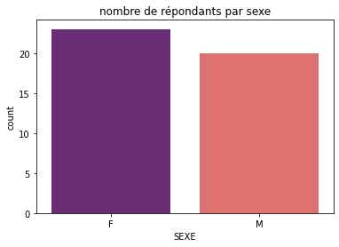

```python
sns.countplot(x = 'SEXE', data = df, palette = 'magma')
plt.title('nombre de répondants par sexe');
```

on note qu'il y a plus de femmes que d'hommes

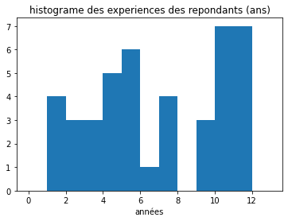

```python
binsize = 1
bins = np.arange(0, 14, binsize)
plt.hist(data = df, x = 'Experience_ans', bins = bins)
plt.title('histograme des experiences des repondants (ans)')
plt.xlabel('années');
```

- on a pas de repondant avec 8 ans d'experience a JTI.
- 14 repondants on plus que 10 and d'experience avec JTI.

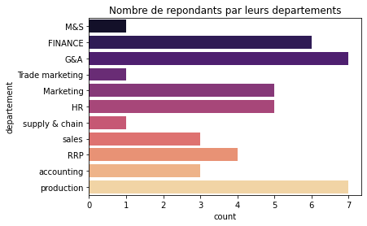

```python
sns.countplot(y = 'Departement_JTI', data = df, palette = 'magma')
plt.title('Nombre de repondants par leurs departements')
plt.ylabel('departement');
```

- les departements les plus presentes sont : production et G&A avec 7 repondants chacun.
- Finance, Marketing et HR viennent en second en termes de fréquence.

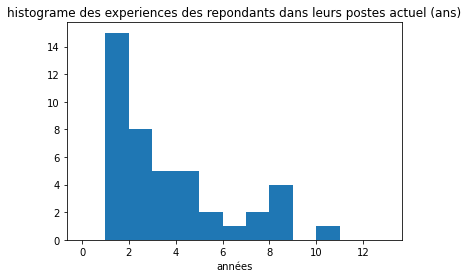

```python
binsize = 1
bins = np.arange(0, 14, binsize)
plt.hist(data = df, x = 'Experience_poste_ans', bins = bins)
plt.title('histograme des experiences des repondants dans leurs postes actuel (ans)')
plt.xlabel('années');
```

- Je remarque que la plupart des répondants n'ont qu'une année d'expérience dans leurs postes actuels.

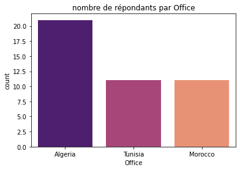

```python
sns.countplot(x = 'Office', data = df, palette = 'magma')
plt.title('nombre de répondants par Office');
```

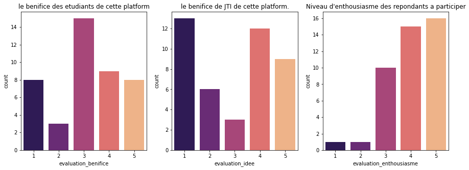

```python
plt.figure(figsize=[15, 5])

# le tracé de gauche
plt.subplot(1,3,1)
sns.countplot(x = 'evaluation_benifice', data = df, palette = 'magma')
plt.title('le benifice des etudiants de cette platform')

# le trace du milieu
plt.subplot(1,3,2)
sns.countplot(x = 'evaluation_idee', data = df, palette = 'magma')
plt.title('le benifice de JTI de cette platform.')

# le tracé à droite
plt.subplot(1,3,3)
sns.countplot(x = 'evaluation_enthousiasme', data = df, palette = 'magma')
plt.title("Niveau d'enthousiasme des repondants a participer");
```

- Pour le benifice des etudiants de la platform, la plupart des repondants ne vois pas la platform tres benificiaire. a un echelle de 5 ( 1 -- > 5 ), la valeur la plus frequente est 3.
- Pour le benifice de l'entreprise JTI de la platform, 13 repondants ont la platform inutile (=1), mais 12 autres l'ont donner la note 4/5 c'est a dire utile.
- Pour l'enthousiasme, la plupart des repondants (plus que 31) sont très heureux de participer à la plateforme (>= 4/5)

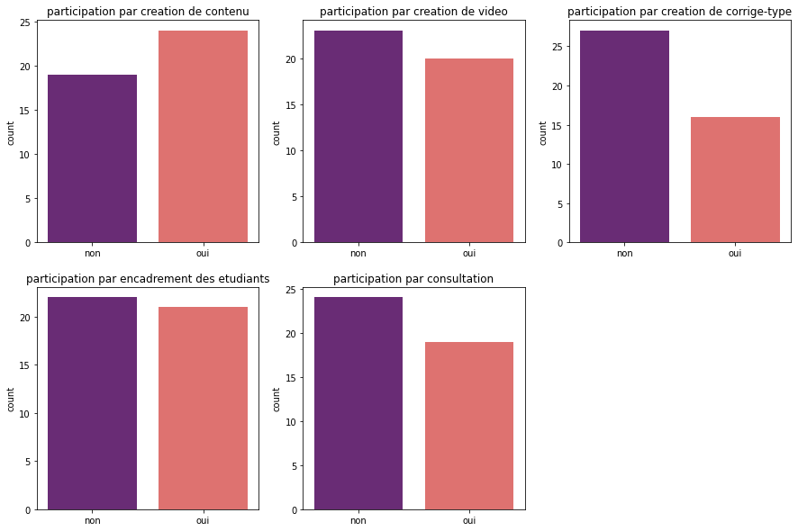

```python
plt.figure(figsize=[15, 10])
names = ['non', 'oui']

plt.subplot(2,3,1)
sns.countplot(x = 'creation_contenu' , data = df, palette = 'magma')
plt.title('participation par creation de contenu')
plt.xlabel('')
plt.xticks(ticks = [0,1], labels= names)

plt.subplot(2, 3,2)
sns.countplot(x = 'creation_video', data = df, palette = 'magma')
plt.title('participation par creation de video')
plt.xlabel('')
plt.xticks(ticks = [0,1], labels= names)

plt.subplot(2,3,3)
sns.countplot(x = 'creation_corrige_type', data = df, palette = 'magma')
plt.title("participation par creation de corrige-type")
plt.xlabel('')
plt.xticks(ticks = [0,1], labels= names)

plt.subplot(2,3,4)
sns.countplot(x = 'encadrement', data = df, palette = 'magma')
plt.title("participation par encadrement des etudiants")
plt.xlabel('')
plt.xticks(ticks = [0,1], labels= names)

plt.subplot(2,3,5)
sns.countplot(x = 'consultation', data = df, palette = 'magma')
plt.title("participation par consultation")
plt.xlabel('')
plt.xticks(ticks = [0,1], labels= names);
```

- la plupart des repondants ne veulent pas participer a creer des corrige-type ni de faire la consultation.
- il y a plus de repondants qui veulent creer de contenu.
- l'encadrement des etudiants et la creation de video aussi n'attirent pas beaucoup de repondants.

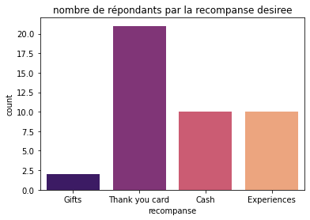

```python
sns.countplot(x = 'recompanse', data = df, palette = 'magma')
plt.title('nombre de répondants par la recompanse desiree');
```

la plupart des repondants veulent une carte de remerciment comme recompanse a leurs participations.

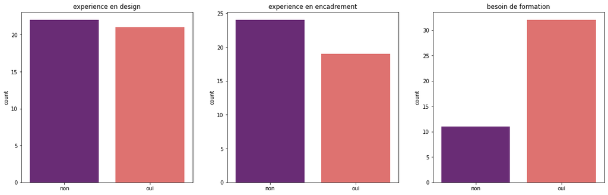

```python
plt.figure(figsize=[20, 6])

# le tracé de gauche
plt.subplot(1,3,1)
sns.countplot(x = 'exp_en_design', data = df, palette = 'magma')
plt.title('experience en design')
plt.xlabel('')
plt.xticks(ticks = [0,1], labels= names)

# le trace du milieu
plt.subplot(1,3,2)
sns.countplot(x = 'exp_en_encadrement', data = df, palette = 'magma')
plt.title('experience en encadrement')
plt.xlabel('')
plt.xticks(ticks = [0,1], labels= names)

# le tracé à droite
plt.subplot(1,3,3)
sns.countplot(x = 'besoin_de_formation', data = df, palette = 'magma')
plt.title("besoin de formation")
plt.xlabel('')
plt.xticks(ticks = [0,1], labels= names);
```

- la plupart n'ont pas d'experience ni en design ni en encadrement et ils ont besoin d'atteindre une formation pour pouvoir participer a la platform

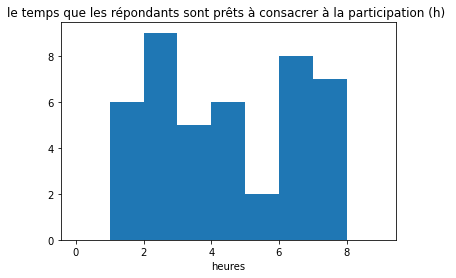

```python
binsize = 1
bins = np.arange(0, 10, binsize)
plt.hist(data = df, x = 'Heure', bins = bins)
plt.title('le temps que les répondants sont prêts à consacrer à la participation (h) ')
plt.xlabel('heures');
```

## Analyse Multivariee:

Puisque je suis intéressé de savoir à quel point les employés sont intéressés à participer à la plateforme et combien d'heures ils sont prêts à consacrer chaque semaine, je considérerai les variables: "Evaluation_enthousiasme" et "Heures" mes variables d'intérêt et je chercherai toute corrélation entre eux et le reste des variables.

### Variables Qualitatives :

Je vais commencer par la corrélation avec mes variables qualitatives

```python
pd.crosstab(df['evaluation_enthousiasme'] , df['SEXE'])
```

| SEXE evaluation_enthousiasme | F | M |
| --- | --- | --- |
| 1 | 1 | 0 |
| 2 | 0 | 1 |
| 3 | 7 | 3 |
| 4 | 7 | 8 |
| 5 | 8 | 8 |

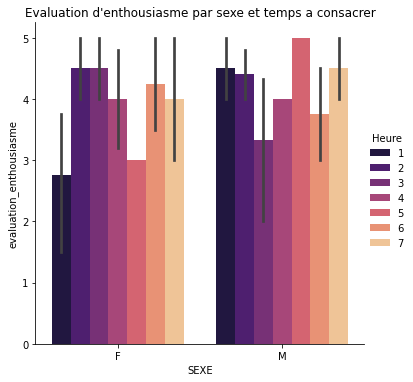

```python
sns.catplot(x="SEXE", y = 'evaluation_enthousiasme',hue= 'Heure', kind="bar", data=df, palette = 'magma')
plt.title("Evaluation d'enthousiasme par sexe et temps a consacrer");
```

- en moyenne, les hommes sont plus enthousiastes que les femmes à participer
- les hommes sont pres a consacrer plus de temps a la participation.

```python
pd.crosstab(df['evaluation_enthousiasme'],df['Departement_JTI'])
```

| Departement_JTI evaluation_enthousiasme | FINANCE | G&A | HR | M&S | Marketing | RRP | Trade marketing | accounting | production | sales | supply & chain |
| --- | --- | --- | --- | --- | --- | --- | --- | --- | --- | --- | --- |
| 1 | 1 | 0 | 0 | 0 | 0 | 0 | 0 | 0 | 0 | 0 | 0 |
| 2 | 0 | 1 | 0 | 0 | 0 | 0 | 0 | 0 | 0 | 0 | 0 |
| 3 | 0 | 1 | 1 | 0 | 2 | 2 | 0 | 1 | 1 | 2 | 0 |
| 4 | 2 | 4 | 0 | 0 | 2 | 1 | 1 | 2 | 2 | 0 | 1 |
| 5 | 3 | 1 | 4 | 1 | 1 | 1 | 0 | 0 | 4 | 1 | 0 |

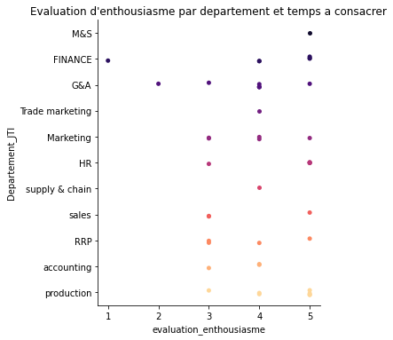

```python
sns.catplot(y="Departement_JTI", x = 'evaluation_enthousiasme',data=df, palette = 'magma')
plt.title("Evaluation d'enthousiasme par departement et temps a consacrer");
```

- les répondants les moins enthousiastes travaillent dans les départements G&A et Finance.

```python
pd.crosstab(df['evaluation_enthousiasme'],df['Office'])
```

| Office evaluation_enthousiasme | Algeria | Morocco | Tunisia |
| --- | --- | --- | --- |
| 1 | 1 | 0 | 0 |
| 2 | 0 | 0 | 1 |
| 3 | 5 | 3 | 2 |
| 4 | 5 | 3 | 7 |
| 5 | 10 | 5 | 1 |

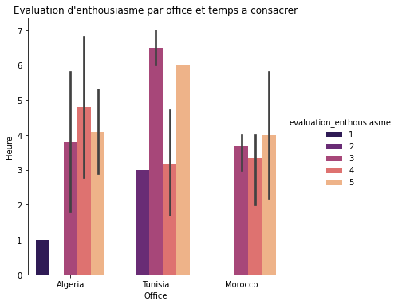

```python
sns.catplot(x="Office", y = 'Heure',hue='evaluation_enthousiasme',kind="bar" ,data=df, palette = 'magma')
plt.title("Evaluation d'enthousiasme par office et temps a consacrer");
```

```python
pd.crosstab(df['evaluation_enthousiasme'],df['recompanse'])
```

| recompanse evaluation_enthousiasme | Cash | Experiences | Gifts | Thank you card |
| --- | --- | --- | --- | --- |
| 1 | 0 | 0 | 0 | 1 |
| 2 | 0 | 0 | 1 | 0 |
| 3 | 5 | 2 | 0 | 3 |
| 4 | 4 | 4 | 0 | 7 |
| 5 | 1 | 4 | 1 | 10 |

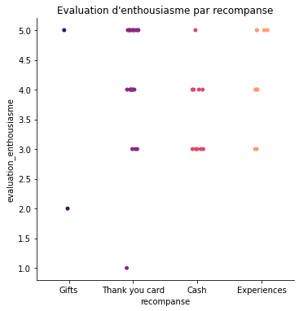

```python
sns.catplot(x="recompanse", y = 'evaluation_enthousiasme' ,data=df, palette = 'magma')
plt.title("Evaluation d'enthousiasme par recompanse");
```

- il n'y a pas une correlation entre la recompanse souhaite et l'enthousiasme a participer.